# Homework 1

*Below, the summary shows that there are approximately 10 times as many schools that are not considered elite than there are schools that fit the elite criteria.*

```
## Elite Colleges Summary
```

```
##  No Yes
## 699  78
```

*Below, the plots demonstrate the relationship between how many out of state students a school has and it’s status as elite or not. Elite schools on average have more out of state students than non-elite schools.*

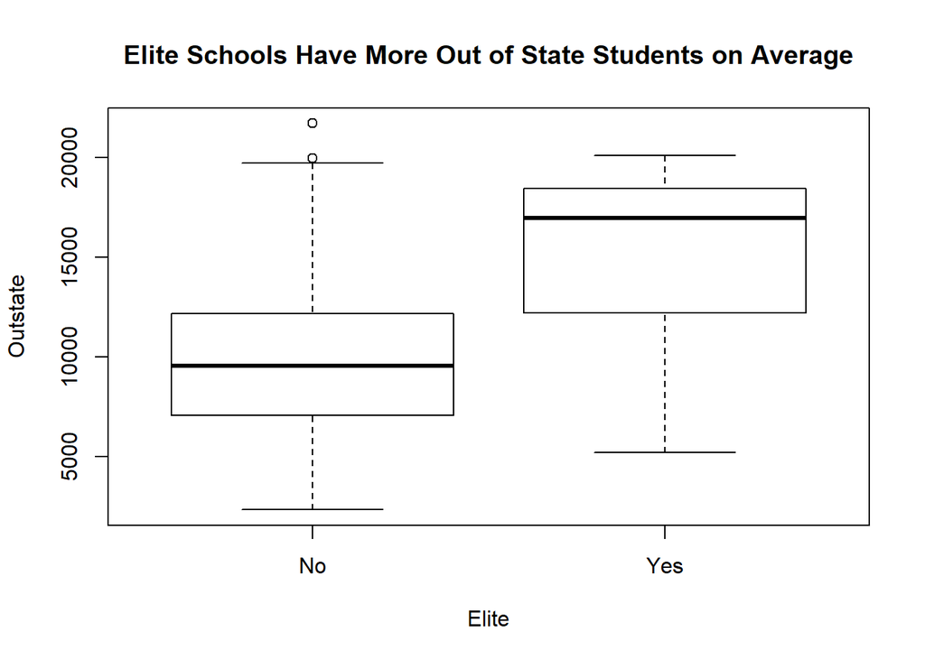

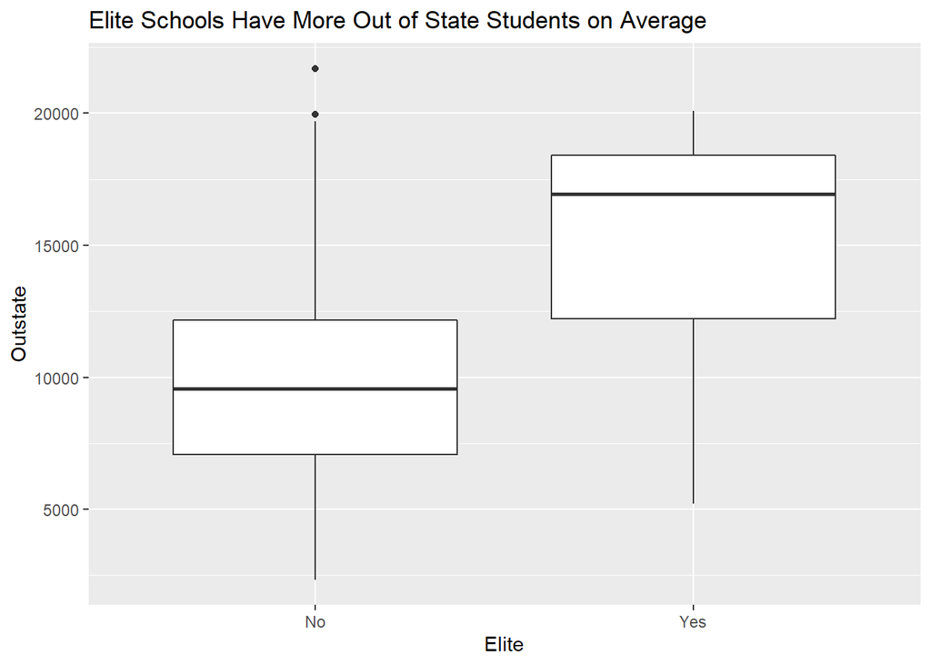

22. Use the hist() function to produce some histograms with diﬀering numbers of bins for a few of the quantitative variables. You may ﬁnd the command par(mfrow=c(2,2)) useful: it will divide the print window into four regions so that four plots can be made simultaneously. Modifying the arguments to this function will divide the screen in other ways.

*Below, the requested histograms were made in base r and ggplot. We can see acceptance and enrollment are not normal distributions, with a small portion of schools getting a much higher amount acceptance and enrollment. Grad rate and the PhD status of teachers are closer to a normal distribution.*

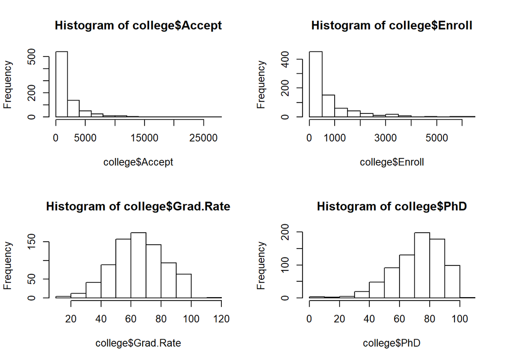

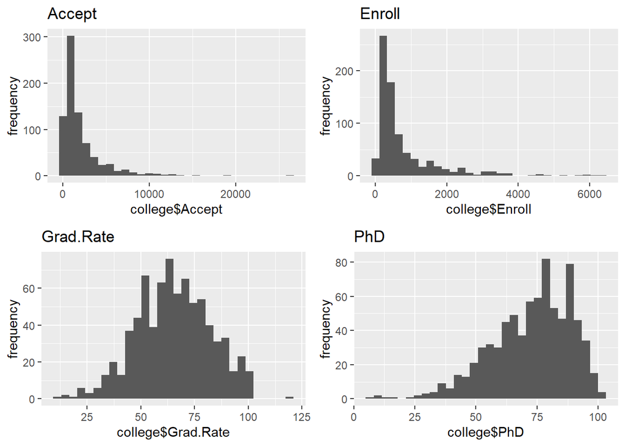

6. Continue exploring the data, and provide a brief summary of what you discover.